# Wine Quality Prediction

Notebook designed to predict wine quality based on $11$ possible features. The approach here is to predict whether the wine is good or bad rather than predicting the quality score of it. Due to that decision, there was a cutoff value to determinate if it is good or bad.Therefore, the prediction will only say if it is a bad or good wine.

**Source:** https://archive.ics.uci.edu/ml/datasets/wine+quality

[figure not shown]

```r
winequality_white <- read_delim("~/GitHub/Wine-Qulity-Prediction/Code/winequality-white.csv",
    delim = ";", escape_double = FALSE, trim_ws = TRUE)

winequality_white$quality_binary <- ifelse(winequality_white$quality > 6, FALSE, TRUE)
```

The cutoff value is 6 for the quality. Therefore there will be un imbalance to treat later on and it is more realistic division in my understanding.

# Exploratory data Analysis and Outlier Treatment

Taking a look into how the data is distributed:

```r
skim(winequality_white)
```

Data summary

| Name | winequality_white |
| --- | --- |
| Number of rows | 4898 |
| Number of columns | 13 |
| _______________________ |  |
| Column type frequency: |  |
| logical | 1 |
| numeric | 12 |
| ________________________ |  |
| Group variables | None |

**Variable type: logical**

| skim_variable | n_missing | complete_rate | mean | count |
| --- | --- | --- | --- | --- |
| quality_binary | 0 | 1 | 0.78 | TRU: 3838, FAL: 1060 |

**Variable type: numeric**

| skim_variable | n_missing | complete_rate | mean | sd | p0 | p25 | p50 | p75 | p100 | hist |
| --- | --- | --- | --- | --- | --- | --- | --- | --- | --- | --- |
| fixed acidity | 0 | 1 | 6.85 | 0.84 | 3.80 | 6.30 | 6.80 | 7.30 | 14.20 | ▁▇▁▁▁ |
| volatile acidity | 0 | 1 | 0.28 | 0.10 | 0.08 | 0.21 | 0.26 | 0.32 | 1.10 | ▇▅▁▁▁ |
| citric acid | 0 | 1 | 0.33 | 0.12 | 0.00 | 0.27 | 0.32 | 0.39 | 1.66 | ▇▆▁▁▁ |
| residual sugar | 0 | 1 | 6.39 | 5.07 | 0.60 | 1.70 | 5.20 | 9.90 | 65.80 | ▇▁▁▁▁ |
| chlorides | 0 | 1 | 0.05 | 0.02 | 0.01 | 0.04 | 0.04 | 0.05 | 0.35 | ▇▁▁▁▁ |
| free sulfur dioxide | 0 | 1 | 35.31 | 17.01 | 2.00 | 23.00 | 34.00 | 46.00 | 289.00 | ▇▁▁▁▁ |
| total sulfur dioxide | 0 | 1 | 138.36 | 42.50 | 9.00 | 108.00 | 134.00 | 167.00 | 440.00 | ▂▇▂▁▁ |
| density | 0 | 1 | 0.99 | 0.00 | 0.99 | 0.99 | 0.99 | 1.00 | 1.04 | ▇▂▁▁▁ |
| pH | 0 | 1 | 3.19 | 0.15 | 2.72 | 3.09 | 3.18 | 3.28 | 3.82 | ▁▇▇▂▁ |
| sulphates | 0 | 1 | 0.49 | 0.11 | 0.22 | 0.41 | 0.47 | 0.55 | 1.08 | ▃▇▂▁▁ |
| alcohol | 0 | 1 | 10.51 | 1.23 | 8.00 | 9.50 | 10.40 | 11.40 | 14.20 | ▃▇▆▃▁ |
| quality | 0 | 1 | 5.88 | 0.89 | 3.00 | 5.00 | 6.00 | 6.00 | 9.00 | ▁▅▇▃▁ |

As per the data quality, we have no missing values at any column and the types seems to be ok too.Now lets seek for possible outliers. First, with the ones with bigger $sd$:

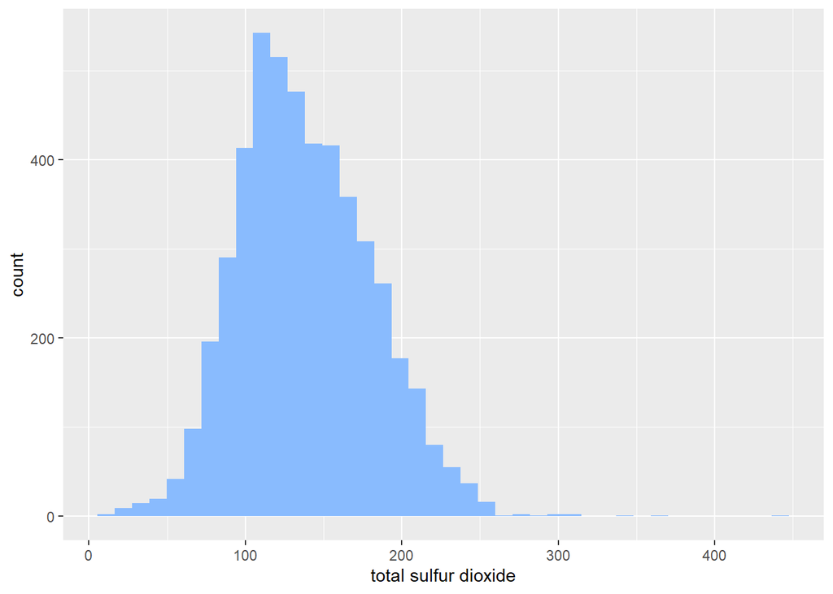

```r
ggplot(winequality_white, aes(x=`total sulfur dioxide`)) + geom_histogram(bins = 40, fill = '#89BBFE')
```

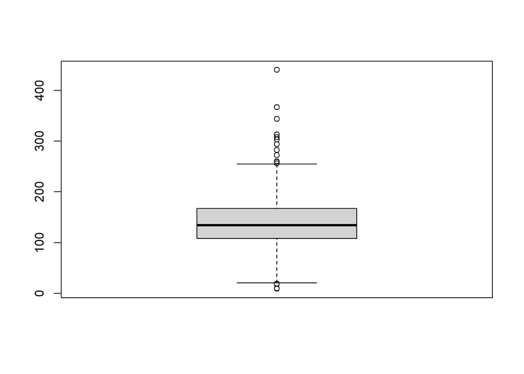

```
##  [1] 272.0 313.0 260.0  19.0 366.5 307.5 256.0 256.0 344.0 282.0 303.0 272.0
## [13]  18.0  18.0 294.0   9.0  10.0 259.0 440.0
```

```r
boxplot(winequality_white$`total sulfur dioxide`)$out
```

Many outliers to get rid of, digging further:

```r
library(EnvStats)
test <- rosnerTest(winequality_white$`total sulfur dioxide`,
  k = 20,
  alpha = 0.1
)
sum(test$all.stats$Outlier)
```

```
## [1] 3
```

For Rosners, we have at least 3 outliers, but as the sample ig big enough compared to the number of outliers found, I’ll remove all of the ones that fits the *Quantile* method:

```r
Q <- quantile(winequality_white$`total sulfur dioxide`, probs=c(.25, .75), na.rm = FALSE)
iqr <- IQR(winequality_white$`total sulfur dioxide`)
up <-  Q[2]+1.5*iqr # Upper Range
low <- Q[1]-1.5*iqr # Lower Range
winequality_white <- subset(winequality_white, winequality_white$`total sulfur dioxide` > (Q[1] - 1.5*iqr) & winequality_white$`total sulfur dioxide` < (Q[2]+1.5*iqr))
```

The new distribution without the outliers looks like this:

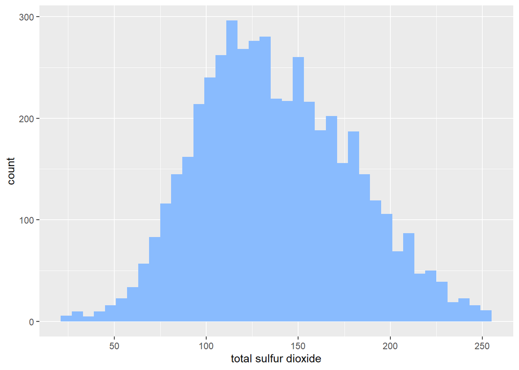

```r
ggplot(winequality_white, aes(x=`total sulfur dioxide`)) + geom_histogram(bins = 40, fill = '#89BBFE')
```

Now, with the second biggest $sd$:

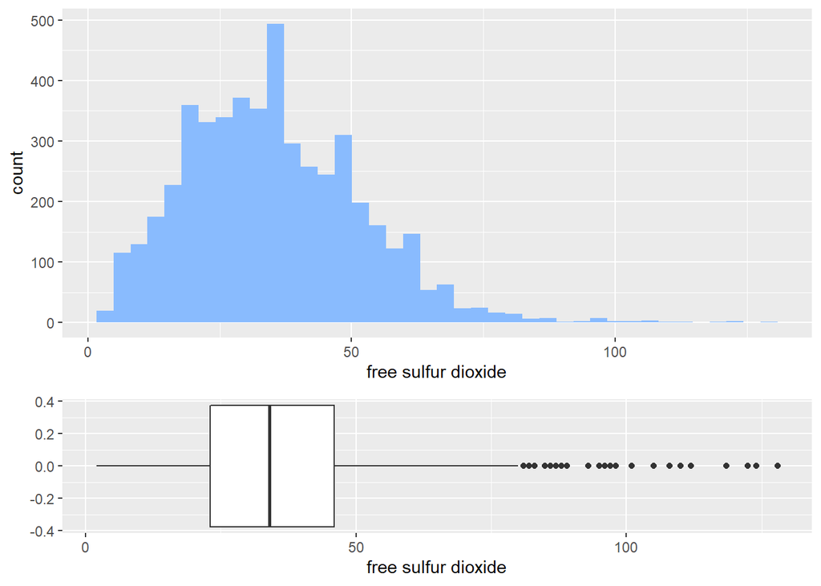

```r
hist <- ggplot(winequality_white, aes(x=`free sulfur dioxide`)) + geom_histogram(bins = 40, fill = '#89BBFE')
box <- ggplot(winequality_white, aes(`free sulfur dioxide`)) + geom_boxplot()
plot_grid(hist, box,
                   ncol = 1, rel_heights = c(2, 1),
                   align = 'v', axis = 'lr')
```

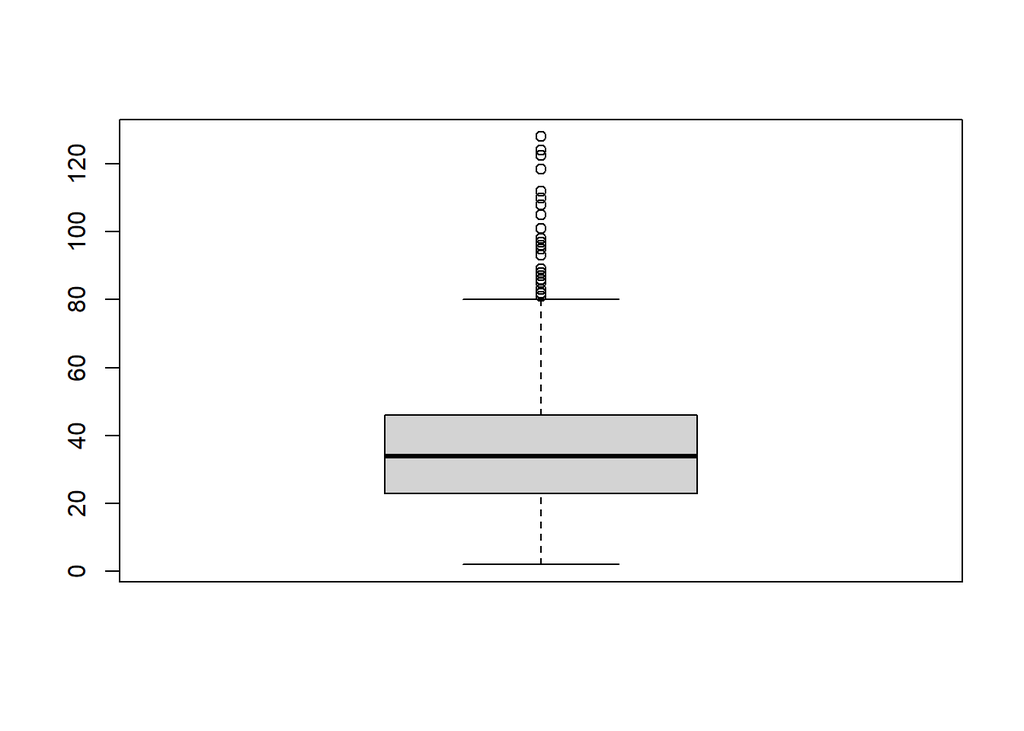

```
##  [1]  81.0  82.0  87.0  87.0  83.0 122.5  83.0  81.0  88.0  82.0 118.5  81.0
## [13]  96.0  83.0  83.0 128.0 110.0  85.0  89.0  86.0  86.0  96.0  96.0  93.0
## [25]  85.0  81.0  95.0 124.0  87.0  87.0 105.0 105.0 101.0 101.0 108.0 108.0
## [37]  98.0  98.0 112.0 108.0  98.0  81.0  81.0  81.0  97.0
```

```r
boxplot(winequality_white$`free sulfur dioxide`)$out
```

Too many outliers according to the boxplot, let’s try Rosner’s test:

```r
library(EnvStats)
test <- rosnerTest(winequality_white$`free sulfur dioxide`,
  k = 55,
  alpha = 0.1
)
sum(test$all.stats$Outlier)
```

```
## [1] 11
```

Now, at least $11$ outliers with that test. Again, I’ll opt for the removal, since the number is not that high compared to the number of observations.

```r
Q <- quantile(winequality_white$`free sulfur dioxide`, probs=c(.25, .75), na.rm = FALSE)
iqr <- IQR(winequality_white$`free sulfur dioxide`)
up <-  Q[2]+1.5*iqr # Upper Range
low<- Q[1]-1.5*iqr # Lower Range
winequality_white<- subset(winequality_white, winequality_white$`free sulfur dioxide` > (Q[1] - 1.5*iqr) & winequality_white$`free sulfur dioxide` < (Q[2]+1.5*iqr))
```

The new distribuition looks like that now:

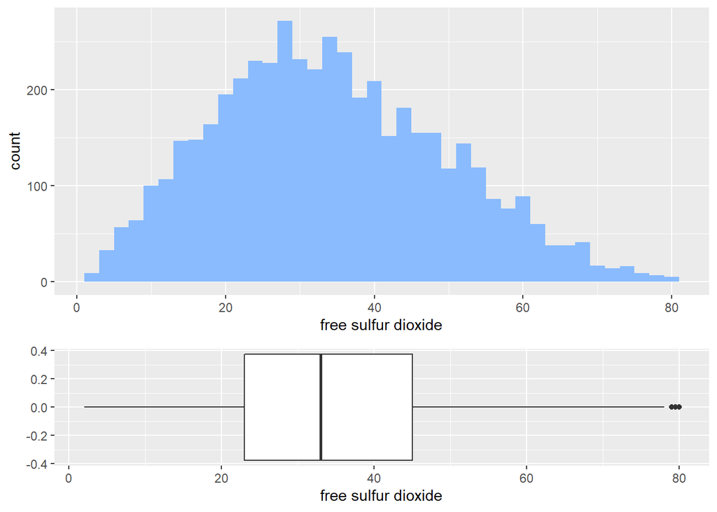

```r
hist <- ggplot(winequality_white, aes(x=`free sulfur dioxide`)) + geom_histogram(bins = 40, fill = '#89BBFE')
box <- ggplot(winequality_white, aes(x=`free sulfur dioxide`)) + geom_boxplot()
plot_grid(hist, box,
                   ncol = 1, rel_heights = c(2, 1),
                   align = 'v', axis = 'lr')
```

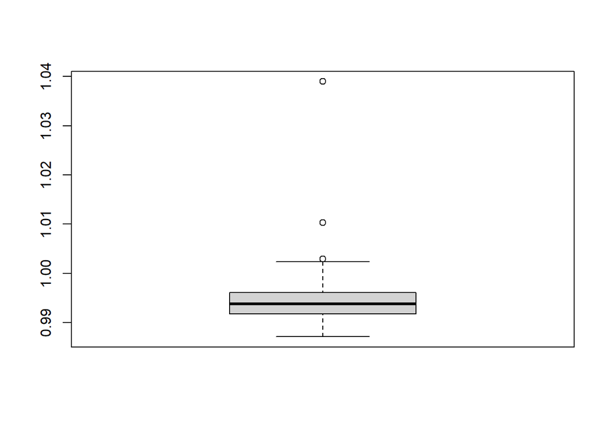

```r
outliers <- boxplot(winequality_white$density)$out
```

Density also has it’s problems, but no big deal. As the deviation here is small, I’ll simple substitute with the median.

```r
winequality_white$density[winequality_white$density %in% outliers] <- median(winequality_white$density)
```

## Exploratory data analysis

Starting with a basic correlation plot

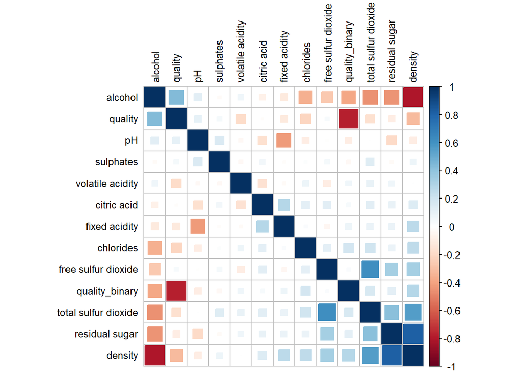

```r
correlation <- cor(winequality_white)
corrplot(correlation, number.cex = .9, method = "square",
         hclust.method = "ward", order = "FPC",
         type = "full", tl.cex=0.8,tl.col = "black")
```

We can see that one of the most correlated variables to the target is alcohol.

## Feature Importance

After the exploratory data analysis, we have a good idea about the main features that impacts the target variable. But now I’l take a Boruta test to see the most relevant features to out analysis.

```r
winequality_white <- winequality_white[-c(12)]
boruta.bank_train <- Boruta(quality_binary~., data = winequality_white, doTrace = 2)
```

```
##  1. run of importance source...
```

```
##  2. run of importance source...
```

```
##  3. run of importance source...
```

```
##  4. run of importance source...
```

```
##  5. run of importance source...
```

```
##  6. run of importance source...
```

```
##  7. run of importance source...
```

```
##  8. run of importance source...
```

```
##  9. run of importance source...
```

```
##  10. run of importance source...
```

```
##  11. run of importance source...
```

```
## After 11 iterations, +17 secs:
```

```
##  confirmed 11 attributes: `citric acid`, `fixed acidity`, `free sulfur dioxide`, `residual sugar`, `total sulfur dioxide` and 6 more;
```

```
##  no more attributes left.
```

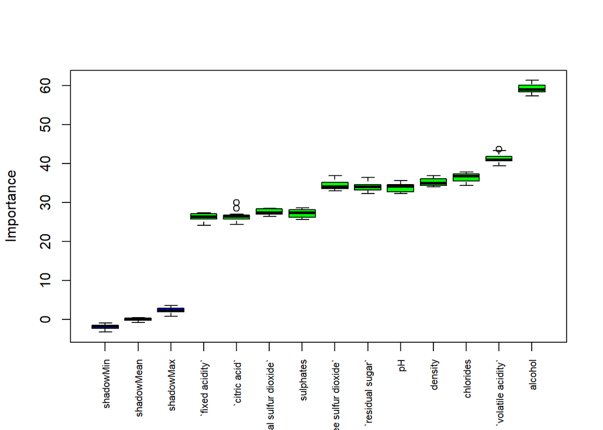

```r
plot(boruta.bank_train, xlab = "", xaxt = "n")
lz<-lapply(1:ncol(boruta.bank_train$ImpHistory),function(i)
boruta.bank_train$ImpHistory[is.finite(boruta.bank_train$ImpHistory[,i]),i])
names(lz) <- colnames(boruta.bank_train$ImpHistory)
Labels <- sort(sapply(lz,median))
axis(side = 1,las=2,labels = names(Labels),
at = 1:ncol(boruta.bank_train$ImpHistory), cex.axis = 0.7)
```

```r
set.seed(12)
split <- sample.split(winequality_white$quality_binary, SplitRatio = 0.8)

train_reg <- subset(winequality_white, split == "TRUE")
test_reg <- subset(winequality_white, split == "FALSE")

logistic_model <- glm(quality_binary ~ alcohol + `volatile acidity` + chlorides  + `free sulfur dioxide` + `residual sugar` + pH + sulphates,
                      data = train_reg,
                      family = "binomial")

summary(logistic_model)
```

```
##
## Call:
## glm(formula = quality_binary ~ alcohol + `volatile acidity` +
##     chlorides + `free sulfur dioxide` + `residual sugar` + pH +
##     sulphates, family = "binomial", data = train_reg)
##
## Deviance Residuals:
##     Min       1Q   Median       3Q      Max
## -2.9841   0.1805   0.4366   0.6717   1.9745
##
## Coefficients:
##                        Estimate Std. Error z value Pr(>|z|)
## (Intercept)           13.569843   1.134212  11.964  < 2e-16 ***
## alcohol               -0.874285   0.048276 -18.110  < 2e-16 ***
## `volatile acidity`     3.997282   0.523301   7.639 2.20e-14 ***
## chlorides             20.846054   4.353779   4.788 1.68e-06 ***
## `free sulfur dioxide` -0.012018   0.003166  -3.796 0.000147 ***
## `residual sugar`      -0.047166   0.011332  -4.162 3.15e-05 ***
## pH                    -1.092367   0.287510  -3.799 0.000145 ***
## sulphates             -1.176342   0.357906  -3.287 0.001014 **
## ---
## Signif. codes:  0 '***' 0.001 '**' 0.01 '*' 0.05 '.' 0.1 ' ' 1
##
## (Dispersion parameter for binomial family taken to be 1)
##
##     Null deviance: 4047.7  on 3866  degrees of freedom
## Residual deviance: 3336.2  on 3859  degrees of freedom
## AIC: 3352.2
##
## Number of Fisher Scoring iterations: 6
```

After exploring the possible models, the one with best AIC was the one above. Now let’s see what would be the best threshold for our model.

```r
library(pROC)
```

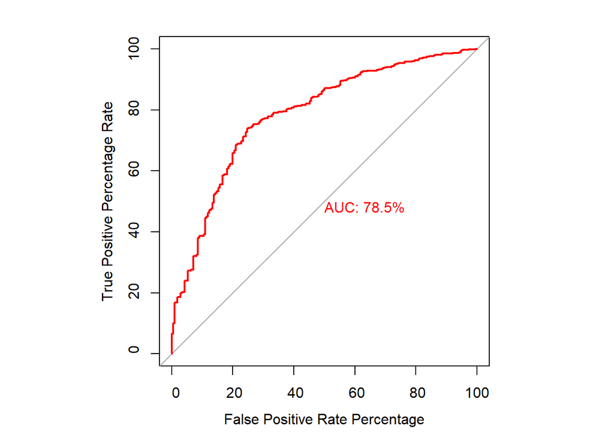

```
##
## Call:
## roc.default(response = test_reg$quality_binary, predictor = rTest,     percent = TRUE, plot = TRUE, legacy.axes = TRUE, xlab = "False Positive Rate Percentage",     ylab = "True Positive Percentage Rate", col = "red", print.auc = TRUE)
##
## Data: rTest in 210 controls (test_reg$quality_binary FALSE) < 757 cases (test_reg$quality_binary TRUE).
## Area under the curve: 78.5%
```

```r
response <- predict(logistic_model,
                       test_reg, type = "response")


rTest <- logit_to_probability(response)

par(pty = "s")
roc(test_reg$quality_binary, rTest, plot=TRUE, legacy.axes=TRUE, percent = TRUE,
    xlab="False Positive Rate Percentage", ylab="True Positive Percentage Rate", col="red", print.auc=TRUE)
```

```r
roc.info <- roc(test_reg$quality_binary, rTest, legacy.axes=TRUE)
roc.df <- data.frame(
  tpp=roc.info$sensitivities*100,
  fpp=(1- roc.info$specificities)*100,
  thresholds=roc.info$thresholds
)
```

In a imaginary situation, where we want to prevent wine that are bad to be classified as good, we need to reduce the times where the model say it is FALSE but actually is TRUE. At this moment, False Positive means that the model said the wine was bad but actually is good (pay less drink something good). Looking at a threshold that makes True positive higher, while not caring too much about False Positive.

```r
roc.df %>% filter(roc.df$tpp > 80, roc.df$tpp < 90)
```

```
##          tpp      fpp thresholds
## 1   89.96037 57.61905  0.5776285
## 2   89.96037 57.14286  0.5792522
## 3   89.82827 57.14286  0.5811188
## 4   89.69617 57.14286  0.5815837
## 5   89.69617 56.66667  0.5826068
## 6   89.69617 56.19048  0.5856203
## 7   89.56407 56.19048  0.5886071
## 8   89.56407 55.23810  0.5894651
## 9   89.43197 55.23810  0.5899509
## 10  89.29987 55.23810  0.5920138
## 11  89.16777 55.23810  0.5945020
## 12  88.90357 55.23810  0.5967348
## 13  88.77147 55.23810  0.5986276
## 14  88.63937 55.23810  0.5992412
```

[output cut: 101 more lines]

```r
predict_reg <- ifelse(rTest > 0.58, 1, 0)

confMatrix <- table(test_reg$quality_binary, predict_reg)
confMatrix
```

```
##        predict_reg
##           0   1
##   FALSE  90 120
##   TRUE   76 681
```

```r
accuracy <- (confMatrix[1,1] + confMatrix[2,2])/(sum(confMatrix))
accuracy
```

```
## [1] 0.7973113
```

```r
precicion <- (confMatrix[2,2])/(confMatrix[2,2] + confMatrix[1,2])
precicion
```

```
## [1] 0.8501873
```

```r
recall <- (confMatrix[2,2])/(confMatrix[2,1] + confMatrix[2,2])
recall
```

```
## [1] 0.8996037
```

```r
f1 <- 2 * (precicion * recall) / (precicion + recall)
f1
```

```
## [1] 0.8741977
```

As we are more worried with the False Negatives, the Recall is more adequate to our performance measure.

*BUT*, the imbalance is a big problem. Those metrics are not that good indicators for imbalanced datasets. Let’s try to deal with it

## Ensambling

As the data is imbalanced, let’s try to apply an ensemble method to evaluate our model better:

```r
badWines <- train_reg[train_reg$quality_binary == TRUE,]
goodWines <- train_reg[train_reg$quality_binary == FALSE,]

train1 <- get_train_batch(badWines, goodWines, 1, 1008)
model1 <- train_glm(train1)
train2 <- get_train_batch(badWines, goodWines,1008, 2016);
model2 <- train_glm(train2)
train3 <- get_train_batch(badWines, goodWines,2016, 3024);
model3 <- train_glm(train3)

finalModel <- vector()
i <- 1
for (i in 1:length(model1)) {
  result <- model1[i] + model2[i] + model3[i]
  if (result > 1) {
    finalModel[i] <- 1
  } else {
    finalModel[i] <- 0
  }
  i <- i + 1
}
```

Here, the dataset is divided into three. Each one has the same proportion of bad and good wines. Then, the model is created and the result is computed using a Majority Vote method. Now, the metrics are good and with more confidence to it.

```r
confMatrix <- table(test_reg$quality_binary, finalModel)
confMatrix
```

```
##        finalModel
##           0   1
##   FALSE  75 135
##   TRUE   61 696
```

```r
accuracy <- (confMatrix[1,1] + confMatrix[2,2])/(sum(confMatrix))
accuracy
```

```
## [1] 0.7973113
```

```r
precicion <- (confMatrix[2,2])/(confMatrix[2,2] + confMatrix[1,2])
precicion
```

```
## [1] 0.8375451
```

```r
recall <- (confMatrix[2,2])/(confMatrix[2,1] + confMatrix[2,2])
recall
```

```
## [1] 0.9194188
```

```r
f1 <- 2 * (precicion * recall) / (precicion + recall)
f1
```

```
## [1] 0.8765743
```

Ensambling the data was not too helpful here. Even with good results, they were slightly better.

To guarantee the prediction threshold, I’ll check for one of the created datasets

```r
testModel <- glm(quality_binary ~ alcohol + `volatile acidity` + chlorides + density + `free sulfur dioxide` + `residual sugar` + pH + sulphates,
                      data = train1,
                      family = "binomial")

response <- predict(testModel,
                       test_reg, type = "response")

rTest <- logit_to_probability(response)

roc.info <- roc(test_reg$quality_binary, rTest, legacy.axes=TRUE)
roc.df <- data.frame(
  tpp=roc.info$sensitivities*100,
  fpp=(1- roc.info$specificities)*100,
  thresholds=roc.info$thresholds
)

roc.df %>% filter(roc.df$tpp > 80, roc.df$tpp < 90)
```

```
##          tpp      fpp thresholds
## 1   89.96037 62.38095  0.1670042
## 2   89.82827 62.38095  0.1677294
## 3   89.69617 62.38095  0.1682750
## 4   89.69617 61.90476  0.1688205
## 5   89.56407 61.90476  0.1696829
## 6   89.43197 61.90476  0.1700481
## 7   89.29987 61.90476  0.1705280
## 8   89.29987 61.42857  0.1735675
## 9   89.16777 61.42857  0.1762660
## 10  89.03567 61.42857  0.1764990
## 11  88.90357 61.42857  0.1767617
## 12  88.90357 60.95238  0.1778673
## 13  88.90357 60.47619  0.1804140
## 14  88.90357 60.00000  0.1830814
```

[output cut: 109 more lines]

# Conclusion

Exploring Logistic Regression is challenging and can go much further then what was here covered. But for a first analysis is good enough.